# Lab 2: Introduction to Python (continued)

In **Lab 1**, we learned how to:

1. Install and import packages
2. Load CSV data into pandas
3. Do basic inspection with `.head()`, `.info()`, `.describe()`
4. Create, modify, and drop variables
5. Do simple subsetting and cleaning

In **Lab 2**, we will:

1. Load an Excel file with soda price data
2. Explore and clean the dataset
3. Practice a few small coding tasks during the lab

## 1. Setup and load the Excel data

First, we import the packages we need and load the dataset `sodaprice.xlsx`.

```python
# make sure to have these packages installed, if not, run the following command in Anaconda Prompt terminal
# conda install -c conda-forge pandas numpy openpyxl matplotlib
```

```python
import os
import pandas as pd
import numpy as np

# Read the Excel file (make sure sodaprice.xlsx is in the same folder as this notebook)
df = pd.read_excel("sodaprice.xlsx")

df.head()
```

|  | soda_price | propblack | income | county | New Jersey |
| --- | --- | --- | --- | --- | --- |
| 0 | 1.12 | 0.171154 | 44534.0 | 18 | 1 |
| 1 | 1.06 | 0.171154 | 44534.0 | 18 | 1 |
| 2 | 1.06 | 0.047360 | 41164.0 | 12 | 1 |
| 3 | 1.12 | 0.052839 | 50366.0 | 10 | 1 |
| 4 | 1.12 | 0.034480 | 72287.0 | 10 | 1 |

```python
# Basic info and summary statistics
df.info()
```

```
<class 'pandas.core.frame.DataFrame'>
RangeIndex: 410 entries, 0 to 409
Data columns (total 5 columns):
 #   Column      Non-Null Count  Dtype
---  ------      --------------  -----
 0   soda_price  402 non-null    float64
 1   propblack   409 non-null    float64
 2   income      409 non-null    float64
 3   county      410 non-null    int64
 4   New Jersey  410 non-null    int64
dtypes: float64(3), int64(2)
memory usage: 16.1 KB
```

```python
df.describe()
```

|  | soda_price | propblack | income | county | New Jersey |
| --- | --- | --- | --- | --- | --- |
| count | 402.000000 | 409.000000 | 409.000000 | 410.000000 | 410.000000 |
| mean | 1.044876 | 0.113486 | 47053.784841 | 13.658537 | 0.807317 |
| std | 0.088687 | 0.182416 | 13179.286069 | 8.045439 | 0.394888 |
| min | 0.730000 | 0.000000 | 15919.000000 | 1.000000 | 0.000000 |
| 25% | 0.980000 | 0.011649 | 37883.000000 | 6.000000 | 1.000000 |
| 50% | 1.060000 | 0.041444 | 46272.000000 | 14.000000 | 1.000000 |
| 75% | 1.085000 | 0.121059 | 54981.000000 | 20.000000 | 1.000000 |
| max | 1.490000 | 0.981658 | 136529.000000 | 29.000000 | 1.000000 |

## 2. Cleaning and renaming columns

The dataset contains variables such as:

- `soda_price`: price of soda
- `propblack`: proportion of Black residents
- `income`: income level
- `county`: county identifier
- `New Jersey`: indicator for being in New Jersey (1 = NJ, 0 = other)

We will first rename the `New Jersey` column to `new_jersey`, and then check for missing values.

```python
# Rename the 'New Jersey' column to avoid spaces in the column name
df = df.rename(columns={"New Jersey": "new_jersey"})

# Check missing values
df.isna().sum()
```

```
soda_price    8
propblack     1
income        1
county        0
new_jersey    0
dtype: int64
```

### Your Task 1: Proportion of missing values

**Goal:** Compute the **proportion** of missing values for each column.

Hint: Remember that in pandas, booleans `True`/`False` can be treated like `1`/`0`, so `.mean()` on a boolean Series gives a proportion.

```python
# TODO: Calculate the proportion of missing values in each column.
# Hint: use .isna() and .mean()

df.isna().mean()
```

```
soda_price    0.019512
propblack     0.002439
income        0.002439
county        0.000000
new_jersey    0.000000
dtype: float64
```

### 2.1 Simple missing data strategies

Two common simple strategies:

1. **Drop** rows with missing values
2. **Fill** missing values with a summary statistic (e.g., median)

We will create two versions of the data:

1. `df_drop`: all rows with any missing values removed
2. `df_fill`: missing `income` values filled with the median income

```python
# Option 1: Drop rows with any missing values
df_drop = df.dropna()

df_drop.info()
```

```
<class 'pandas.core.frame.DataFrame'>
Index: 401 entries, 0 to 409
Data columns (total 5 columns):
 #   Column      Non-Null Count  Dtype
---  ------      --------------  -----
 0   soda_price  401 non-null    float64
 1   propblack   401 non-null    float64
 2   income      401 non-null    float64
 3   county      401 non-null    int64
 4   new_jersey  401 non-null    int64
dtypes: float64(3), int64(2)
memory usage: 18.8 KB
```

```python
# Option 2: Fill missing income with the median
df_fill = df.copy()

median_income = df_fill["income"].median()
df_fill["income"] = df_fill["income"].fillna(median_income)

df_fill["income"].isna().sum()  # should be 0 after filling
```

```
np.int64(0)
```

### Your Task 2: Fill missing `propblack`

**Goal:** Create a copy of the data and fill missing values in `propblack` with its median.

Complete the code below.

```python
df2 = df.copy()

# TODO: Fill missing propblack with its median and store in a new column 'propblack_fill'

# Step 1: compute the median
median_propblack = df2["propblack"].median()

# Step 2: fill missing values
df2["propblack_fill"] = df2["propblack"].fillna(median_propblack)

# Check results
df2["propblack_fill"].isna().sum()
```

```
np.int64(0)
```

## 3. Creating new variables with pandas and NumPy

We will now create new variables using both pandas operations and NumPy functions.

Examples:

1. Convert `income` to thousands (`income_k`)
2. Standardize soda price (`soda_z`)
3. Create indicator variables using `np.where`

```python
# Income in thousands
df["income_k"] = df["income"] / 1000

df[["income", "income_k"]].head()
```

|  | income | income_k |
| --- | --- | --- |
| 0 | 44534.0 | 44.534 |
| 1 | 44534.0 | 44.534 |
| 2 | 41164.0 | 41.164 |
| 3 | 50366.0 | 50.366 |
| 4 | 72287.0 | 72.287 |

```python
# Revised code: In previous version, when I extracted the values of soda price, we referred to the original data frame.
# This created errors as this array contained missing values. So I revised it to df_drop data frame which was cleaned before.

# Z-score (standardize) soda_price using NumPy
price_array = df_drop["soda_price"].values  # NumPy array

price_mean = np.mean(price_array)
price_std = np.std(price_array)

df_drop["soda_z"] = (df_drop["soda_price"] - price_mean) / price_std

df_drop[["soda_price", "soda_z"]].head()
```

|  | soda_price | soda_z |
| --- | --- | --- |
| 0 | 1.12 | 0.847217 |
| 1 | 1.06 | 0.170681 |
| 2 | 1.06 | 0.170681 |
| 3 | 1.12 | 0.847217 |
| 4 | 1.12 | 0.847217 |

```python
# You may see the warning above. It implies another way to pass values to data frame object.

# Z-score (standardize) soda_price using NumPy
price_array = df_drop["soda_price"].values  # NumPy array

price_mean = np.mean(price_array)
price_std = np.std(price_array)

# This is a different command implied by the warning message.
df_drop.loc[:,"soda_z"] = (df_drop["soda_price"] - price_mean) / price_std

df_drop[["soda_price", "soda_z"]].head()
```

[output not shown]

|  | soda_price | soda_z |
| --- | --- | --- |
| 0 | 1.12 | 0.847217 |
| 1 | 1.06 | 0.170681 |
| 2 | 1.06 | 0.170681 |
| 3 | 1.12 | 0.847217 |
| 4 | 1.12 | 0.847217 |

```python
df_drop.info()
```

```
<class 'pandas.core.frame.DataFrame'>
Index: 401 entries, 0 to 409
Data columns (total 6 columns):
 #   Column      Non-Null Count  Dtype
---  ------      --------------  -----
 0   soda_price  401 non-null    float64
 1   propblack   401 non-null    float64
 2   income      401 non-null    float64
 3   county      401 non-null    int64
 4   new_jersey  401 non-null    int64
 5   soda_z      401 non-null    float64
dtypes: float64(4), int64(2)
memory usage: 21.9 KB
```

### Your Task 3: High income dummy with `np.where`

**Goal:** Create a new variable `high_income` equal to `1` if `income` is greater than the **median** income, and `0` otherwise.

Use `np.where(condition, value_if_true, value_if_false)`.

```python
# TODO: Create a high_income dummy using np.where

income_array = df["income"].values

income_median = np.median(income_array)

df["high_income"] = np.where(income_array > income_median,1,0)

df[["income", "high_income"]].head()
```

|  | income | high_income |
| --- | --- | --- |
| 0 | 44534.0 | 0 |
| 1 | 44534.0 | 0 |
| 2 | 41164.0 | 0 |
| 3 | 50366.0 | 0 |
| 4 | 72287.0 | 0 |

We can similarly use `np.where` to define a **high price** dummy. For example, let's define `high_price = 1` if `soda_price > 1.10`.

```python
df["high_price"] = np.where(df["soda_price"] > 1.10 , 1, 0)

df[["soda_price", "high_price"]].head()
```

|  | soda_price | high_price |
| --- | --- | --- |
| 0 | 1.12 | 1 |
| 1 | 1.06 | 0 |
| 2 | 1.06 | 0 |
| 3 | 1.12 | 1 |
| 4 | 1.12 | 1 |

## 4. Groupby and summary statistics

Now we explore how soda prices differ by groups, such as:

1. New Jersey vs. other states
2. High-income vs. low-income areas

```python
# Mean soda price by New Jersey vs other
df.groupby("new_jersey")["soda_price"].mean()
```

```
new_jersey
0    0.974675
1    1.061508
Name: soda_price, dtype: float64
```

### Your Task 4: Mean soda price by `high_income`

**Goal:** Compute the mean soda price for high-income vs. non-high-income areas.

Use `.groupby()` with the `high_income` dummy.

```python
# TODO: compute mean soda_price by high_income
```

We can also compute multiple statistics at once using `.agg()`.

```python
df.groupby("new_jersey").agg(
    mean_price = ("soda_price", "mean"),
    std_price  = ("soda_price", "std"),
    n          = ("soda_price", "count")
)
```

| new_jersey | mean_price | std_price | n |
| --- | --- | --- | --- |
| 0 | 0.974675 | 0.069483 | 77 |
| 1 | 1.061508 | 0.084579 | 325 |

### Your Task 5: Two-way comparison

**Goal:** Compare mean soda prices across **four** groups defined by:

- `new_jersey` (0/1)
- `high_income` (0/1)

Use a two-variable groupby with a list: `["new_jersey", "high_income"]`.

```python
# TODO: group by both new_jersey and high_income and compute mean soda_price
```

## 5. Visualizing the data with matplotlib

Examples of Histogram, Boxplot, and Scatter

```python
import matplotlib.pyplot as plt
```

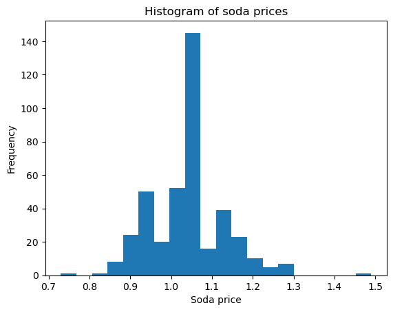

```python
fig1 = plt.figure()
plt.hist(df["soda_price"].dropna(), bins=20)
plt.xlabel("Soda price")
plt.ylabel("Frequency")
plt.title("Histogram of soda prices")
plt.show()
```

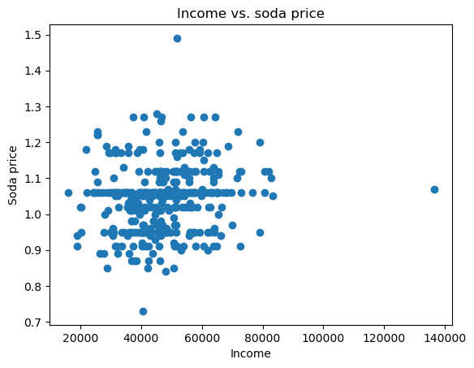

```python
fig2 = plt.figure()
plt.scatter(df["income"], df["soda_price"])
plt.xlabel("Income")
plt.ylabel("Soda price")
plt.title("Income vs. soda price")
```

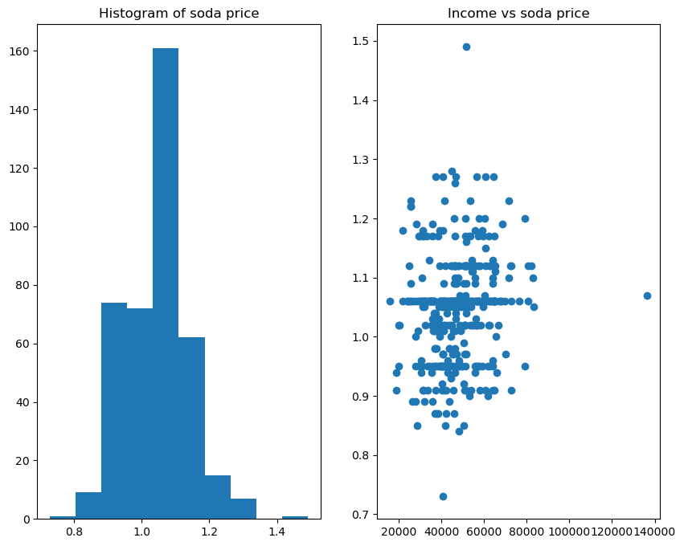

```python
fig3, axs = plt.subplots(1,2, figsize=(10,8))

axs[0].hist(df["soda_price"])
axs[0].set_title("Histogram of soda price")

axs[1].scatter(df["income"], df["soda_price"])
axs[1].set_title("Income vs soda price")

plt.show()
```

```python
fig1.savefig("fig1.png")
fig1.savefig("fig1_updated.png", dpi=500)

fig2.savefig("fig2.pdf")
fig3.savefig("fig3.svg")
```